# Thesis_Bagetto

2026-06-01

The present study was conducted on patients diagnosed with multiple sclerosis, who were followed at the Neurology Department of San Luigi Gonzaga Hospital. Patient selection was based on the ongoing treatment regimen, specifically with Tecfidera, whose active compound is dimethyl fumarate. This oral medication is indicated for the treatment of relapsing-remitting multiple sclerosis (RRMS) and acts as an immunomodulatory agent, contributing to the reduction of relapse frequency while exerting a protective effect on the central nervous system against oxidative stress.

The datasets used in this analysis were imported and prepared in Rstudio. All required packages were loaded from an external script (library.R) to ensure reproducibility and consistency of the computational environment.

The dataset includes the clinical follow-up of patients, each identified by a unique identification code. For each patient, information is available on date of birth, age at the initiation of therapy (T0), sex, smoking status, physical activity level, and body mass index (BMI). In addition, the MEDAS (Mediterranean Diet Adherence Screener) score was considered in order to assess the dietary habits of individual patients. Regarding the clinical follow-up, data were collected at six-month intervals (T0, T6, T12, T18, T24, T30, T36). However, it is important to note that data are not available (NA) for all patients at each time point. From a clinical perspective, in relation to disease progression, the occurrence of new lesions and relapses in the six months preceding each visit were recorded at each time point, such as EDSS (Expanded Disability Status Scale). The primary aim of this study is to investigate patterns of improvement, progression, or stability in disease course over time.

First of all an exploratory data analysis (EDA) was performed to resume the main characteristics of the dataset and evaluate data quality. This included an assessment of the dataset structure, the presence of NA values, and the distribution of the main variables. The dimensions and structure of the dataset were examined to understand the available variables and the number of observations.

```r
str(merged)
```

```
## 'data.frame':    32 obs. of  75 variables:
##  $ ID                      : chr  "TEC01" "TEC02" "TEC03" "TEC04" ...
##  $ data_di_nascita         : chr  "1984-03-13" "1975-08-20" "1991-01-08" "1991-06-01" ...
##  $ MEDAS                   : num  50 42.9 64.3 42.9 64.3 50 42.9 42.9 50 57.1 ...
##  $ CENTRO                  : chr  "CLERICO" "CLERICO" "CLERICO" "CLERICO" ...
##  $ DATA_ESORDIO            : chr  "2015-01-01" "2018-10-01" "2018-05-01" "2020-05-01" ...
##  $ data_diagnosi           : chr  "2017-05-11" "2019-11-29" "2018-09-21" "2020-06-08" ...
##  $ age_at_diagnosis        : int  33 44 27 29 56 23 19 46 NA 63 ...
##  $ data_prelievo_T0        : chr  "2019-10-07" "2020-01-24" "2020-02-07" "2020-06-30" ...
##  $ EDSS_T0                 : num  1 1 0 1 1 1 1 1 NA 1.5 ...
##  $ data_referto_T6         : chr  NA NA "2020-09-22" NA ...
##  $ EDSS_T6                 : num  1 1 1.5 NA NA NA 1 1 NA NA ...
##  $ lesioni_T6              : int  0 0 0 NA NA NA 0 0 NA NA ...
##  $ relapse_T6              : int  0 0 0 NA NA NA 0 0 NA NA ...
##  $ cortisone_T6            : int  0 0 0 NA NA NA 0 0 NA NA ...
```

[output cut: 61 more lines]

```r
dim(merged)
```

```
## [1] 32 75
```

```r
names(merged)
```

```
##  [1] "ID"                       "data_di_nascita"
##  [3] "MEDAS"                    "CENTRO"
##  [5] "DATA_ESORDIO"             "data_diagnosi"
##  [7] "age_at_diagnosis"         "data_prelievo_T0"
##  [9] "EDSS_T0"                  "data_referto_T6"
## [11] "EDSS_T6"                  "lesioni_T6"
## [13] "relapse_T6"               "cortisone_T6"
## [15] "data_referto_T12"         "EDSS_T12"
## [17] "lesioni_T12"              "relapse_T12"
## [19] "cortisone_T12"            "data_referto_T18"
## [21] "EDSS_T18"                 "lesioni_T18"
## [23] "relapse_T18"              "cortisone_T18"
## [25] "data_referto_T24"         "EDSS_T24"
## [27] "lesioni_T24"              "relapse_T24"
## [29] "cortisone_T24"            "data_referto_T30"
```

[output cut: 23 more lines]

The presence of NA values was assessed for each variable. Both the absolute number and the percentage of missing values were calculated to evaluate data completeness.

```
##                       ID          data_di_nascita                    MEDAS
##                        0                        9                       10
##                   CENTRO             DATA_ESORDIO            data_diagnosi
##                        0                        9                        9
##         age_at_diagnosis         data_prelievo_T0                  EDSS_T0
##                        9                        8                        6
##          data_referto_T6                  EDSS_T6               lesioni_T6
##                       24                       23                       22
##               relapse_T6             cortisone_T6         data_referto_T12
##                       22                       22                       21
##                 EDSS_T12              lesioni_T12              relapse_T12
##                       12                       17                       17
##            cortisone_T12         data_referto_T18                 EDSS_T18
##                       17                       24                       23
##              lesioni_T18              relapse_T18            cortisone_T18
##                       24                       24                       23
##         data_referto_T24                 EDSS_T24              lesioni_T24
##                       21                       17                       19
##              relapse_T24            cortisone_T24         data_referto_T30
##                       19                       19                       26
##                 EDSS_T30              lesioni_T30              relapse_T30
##                       25                       25                       25
##            cortisone_T30         data_referto_T36                 EDSS_T36
##                       25                       23                       20
##              lesioni_T36              relapse_T36            cortisone_T36
##                       20                       20                       20
##           cambio_terapia      data_cambio_terapia            nuova_TERAPIA
##                       12                       27                       25
##                     NOTE                  therapy                    naive
##                       16                        0                        6
##         previous_therapy                      sex                      age
##                       24                        1                        9
##                age_at_T0                      bmi                  pyr_mds
##                        9                       11                       11
##            smoking_habit        physical_activity           antibiotic_use
##                        1                       11                        6
##         sequencing_batch                 spike_in       dna_quantification
##                        6                        6                       27
##              sample_type glucocorticoid_treatment         simplified_batch
##                        6                        6                        6
##         disease_activity   sample_collection_date       glc_date_before_t0
##                        6                       13                       23
##             gc_treatment       days_gc_collection            lesion_burden
##                       14                       23                       14
##      bone_marrow_lesions     subtentorial_lesions      gadolinium_contrast
##                       14                       14                       15
##    clinical_presentation            full_recovery       prognosis_at_onset
##                       14                       14                       14
##             percent_th17            treg_il10_pos            treg_cd39_pos
##                       32                       32                       32
```

```
##                       ID          data_di_nascita                    MEDAS
##                      0.0                     28.1                     31.2
##                   CENTRO             DATA_ESORDIO            data_diagnosi
##                      0.0                     28.1                     28.1
##         age_at_diagnosis         data_prelievo_T0                  EDSS_T0
##                     28.1                     25.0                     18.8
##          data_referto_T6                  EDSS_T6               lesioni_T6
##                     75.0                     71.9                     68.8
##               relapse_T6             cortisone_T6         data_referto_T12
##                     68.8                     68.8                     65.6
##                 EDSS_T12              lesioni_T12              relapse_T12
##                     37.5                     53.1                     53.1
##            cortisone_T12         data_referto_T18                 EDSS_T18
##                     53.1                     75.0                     71.9
##              lesioni_T18              relapse_T18            cortisone_T18
##                     75.0                     75.0                     71.9
##         data_referto_T24                 EDSS_T24              lesioni_T24
##                     65.6                     53.1                     59.4
##              relapse_T24            cortisone_T24         data_referto_T30
##                     59.4                     59.4                     81.2
##                 EDSS_T30              lesioni_T30              relapse_T30
##                     78.1                     78.1                     78.1
##            cortisone_T30         data_referto_T36                 EDSS_T36
##                     78.1                     71.9                     62.5
##              lesioni_T36              relapse_T36            cortisone_T36
##                     62.5                     62.5                     62.5
##           cambio_terapia      data_cambio_terapia            nuova_TERAPIA
##                     37.5                     84.4                     78.1
##                     NOTE                  therapy                    naive
##                     50.0                      0.0                     18.8
##         previous_therapy                      sex                      age
##                     75.0                      3.1                     28.1
##                age_at_T0                      bmi                  pyr_mds
##                     28.1                     34.4                     34.4
##            smoking_habit        physical_activity           antibiotic_use
##                      3.1                     34.4                     18.8
##         sequencing_batch                 spike_in       dna_quantification
##                     18.8                     18.8                     84.4
##              sample_type glucocorticoid_treatment         simplified_batch
##                     18.8                     18.8                     18.8
##         disease_activity   sample_collection_date       glc_date_before_t0
##                     18.8                     40.6                     71.9
##             gc_treatment       days_gc_collection            lesion_burden
##                     43.8                     71.9                     43.8
##      bone_marrow_lesions     subtentorial_lesions      gadolinium_contrast
##                     43.8                     43.8                     46.9
##    clinical_presentation            full_recovery       prognosis_at_onset
##                     43.8                     43.8                     43.8
##             percent_th17            treg_il10_pos            treg_cd39_pos
##                    100.0                    100.0                    100.0
```

## Numerical Variables

Descriptive statistics were computed for the main numerical variables, including measures of mean, median, standard deviation (SD) and interquartile range.

The variables analyzed include: - MEDAS score - Age at baseline and age at diagnosis - BMI - EDSS scores at different time points (T0–T36)

```r
vars <- c("MEDAS", "age_at_T0", "age_at_diagnosis", "bmi",
          "EDSS_T0", "EDSS_T6", "EDSS_T12", "EDSS_T18",
          "EDSS_T24", "EDSS_T30", "EDSS_T36")

lapply(vars, function(v) {
  cat("\n\n###", v, "\n")
  print(summary(merged[[v]]))
  print(mean(merged[[v]], na.rm = TRUE))
  print(sd(merged[[v]], na.rm = TRUE))
  print(median(merged[[v]], na.rm = TRUE))
  print(IQR(merged[[v]], na.rm = TRUE))
  print(range(merged[[v]], na.rm = TRUE))
})
```

```
##
##
## ### MEDAS
##    Min. 1st Qu.  Median    Mean 3rd Qu.    Max.    NA's
##   28.60   42.90   46.45   46.76   50.00   64.30      10
## [1] 46.76364
## [1] 9.269743
## [1] 46.45
## [1] 7.1
## [1] 28.6 64.3
##
##
## ### age_at_T0
##    Min. 1st Qu.  Median    Mean 3rd Qu.    Max.    NA's
##   19.00   33.00   44.00   41.13   48.50   58.00       9
## [1] 41.13043
## [1] 10.78848
## [1] 44
## [1] 15.5
## [1] 19 58
##
##
## ### age_at_diagnosis
##    Min. 1st Qu.  Median    Mean 3rd Qu.    Max.    NA's
##   19.00   28.00   37.00   37.91   45.50   63.00       9
## [1] 37.91304
## [1] 11.47691
## [1] 37
## [1] 17.5
## [1] 19 63
##
##
## ### bmi
##    Min. 1st Qu.  Median    Mean 3rd Qu.    Max.    NA's
##   17.10   22.00   24.30   24.57   26.70   34.80      11
## [1] 24.56667
## [1] 3.87522
## [1] 24.3
## [1] 4.7
## [1] 17.1 34.8
```

[output cut: 55 more lines]

```
## [1] 0.8571429
## [1] 0.6267832
## [1] 1
## [1] 0.75
## [1] 0.0 1.5
##
##
## ### EDSS_T36
##    Min. 1st Qu.  Median    Mean 3rd Qu.    Max.    NA's
##   0.000   1.000   1.000   1.167   1.500   3.000      20
## [1] 1.166667
## [1] 0.7784989
## [1] 1
## [1] 0.5
## [1] 0 3
```

```
## [[1]]
## [1] 28.6 64.3
##
## [[2]]
## [1] 19 58
##
## [[3]]
## [1] 19 63
##
## [[4]]
## [1] 17.1 34.8
##
## [[5]]
## [1] 0 2
##
## [[6]]
## [1] 0.0 1.5
##
## [[7]]
## [1] 0 3
##
## [[8]]
## [1] 0.0 1.5
##
## [[9]]
## [1] 0.0 4.5
##
## [[10]]
## [1] 0.0 1.5
##
## [[11]]
## [1] 0 3
```

The distribution of the main numerical variables was assessed using graphical methods, including histograms, Q–Q plots, and boxplots.

Additionally, the Shapiro–Wilk test was performed to formally assess normality. These analyses were used to determine if variables followed a normal distribution and to decide the appropriate statistical methods and representations. It should be noted that the Shapiro–Wilk test is sensitive to sample size; for this reason, during assessing normality graphical analysis was also considered.

The descriptive analysis of the numerical variables offers a summary of the main characteristics of the study population.

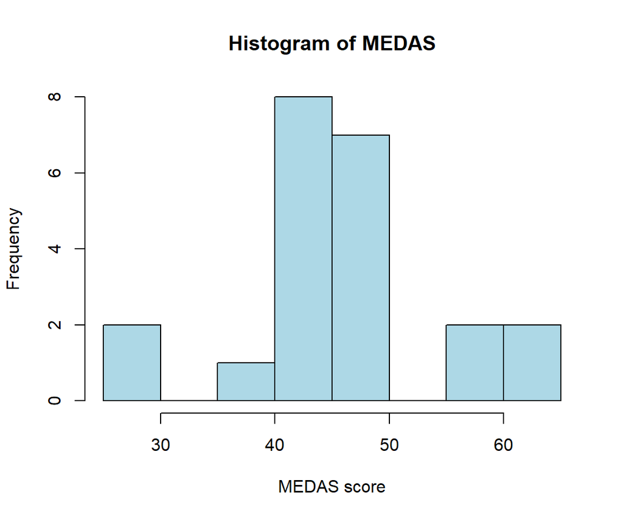

```r
hist(merged$MEDAS,
     main = "Histogram of MEDAS",
     xlab = "MEDAS score",
     col = "lightblue",
     border = "black")
```

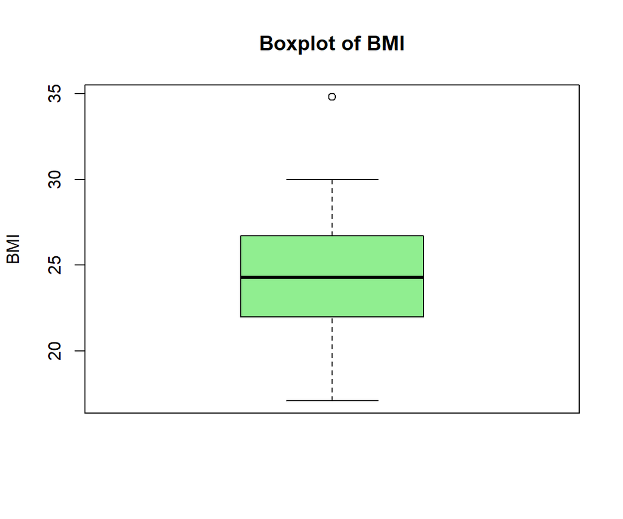

```r
boxplot(merged$bmi,
        main = "Boxplot of BMI",
        ylab = "BMI",
        col = "lightgreen")
```

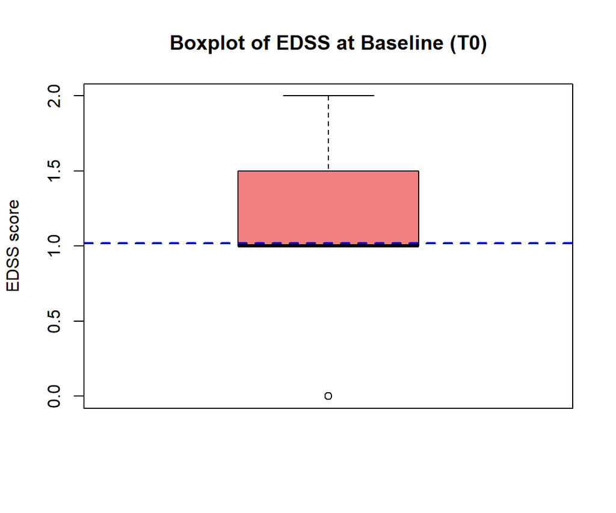

```r
boxplot(merged$EDSS_T0,
        main = "Boxplot of EDSS at Baseline (T0)",
        ylab = "EDSS score",
        col = "lightcoral",
        border = "black")

abline(h = mean(merged$EDSS_T0, na.rm = TRUE),
       col = "blue",
       lwd = 2,
       lty = 2)
```

These findings suggest that non-parametric methods may be more appropriate for the analysis of EDSS, as it is non-normally distributed. Furthermore, the presence of relatively limited variability across different time points highlights the importance of further longitudinal analysis to assess the progression of the disease.

Finally, it is important to highlight that missing data were present at several time points, which could affect the robustness of the analysis and should be taken into account in next steps. Relatively low EDSS scores are consistent with a population affected by RRMS under treatment.

## Categorical Variables

Categorical variables were analyzed using frequency distributions and percentages to characterize the study cohort in terms of lifestyle, clinical perspective, and treatment-related factors.

For a better characterization of disease activity, imaging-related variables, such as bone marrow lesions, subtentorial lesions and gadolinium-enhancing lesions were analyzed. Their presence suggests variability in disease severity and progression in this subset of patients.

```r
# Smoking habit
table(merged$smoking_habit)
```

```
##
##  F  M
## 19 12
```

```r
prop.table(table(merged$smoking_habit)) * 100
```

```
##
##        F        M
## 61.29032 38.70968
```

```r
# Physical activity
merged$physical_activity <- factor(
  merged$physical_activity,
  levels = c("sedentary", "partially_active", "active"),
  ordered = TRUE
)
table(merged$physical_activity)
```

```
##
##        sedentary partially_active           active
##                7                9                5
```

```r
prop.table(table(merged$physical_activity)) * 100
```

```
##
##        sedentary partially_active           active
##         33.33333         42.85714         23.80952
```

```r
# Clinical variables
table(merged$lesion_burden)
```

```
##
##  0  1
## 11  7
```

```r
prop.table(table(merged$lesion_burden)) * 100
```

```
##
##        0        1
## 61.11111 38.88889
```

```r
table(merged$clinical_presentation)
```

```
##
##       brain_stem motor_impairment       multifocal   optic_neuritis
##                5                1                1                5
## sensory_symptoms
##                6
```

```r
prop.table(table(merged$clinical_presentation)) * 100
```

```
##
##       brain_stem motor_impairment       multifocal   optic_neuritis
##        27.777778         5.555556         5.555556        27.777778
## sensory_symptoms
##        33.333333
```

```r
# Demographics
table(merged$sex)
```

```
##
##  F  M
## 19 12
```

```r
prop.table(table(merged$sex)) * 100
```

```
##
##        F        M
## 61.29032 38.70968
```

```r
table(merged$naive)
```

```
##
##  no yes
##   8  18
```

```r
prop.table(table(merged$naive)) * 100
```

```
##
##       no      yes
## 30.76923 69.23077
```

```r
# Treatments
table(merged$antibiotic_use)
```

```
##
##  no yes
##  23   3
```

```r
prop.table(table(merged$antibiotic_use)) * 100
```

```
##
##       no      yes
## 88.46154 11.53846
```

```r
table(merged$glucocorticoid_treatment)
```

```
##
## positive
##       26
```

```r
prop.table(table(merged$glucocorticoid_treatment)) * 100
```

```
##
## positive
##      100
```

```r
table(merged$cambio_terapia)
```

```
##
##  0  1
## 15  5
```

```r
prop.table(table(merged$cambio_terapia)) * 100
```

```
##
##  0  1
## 75 25
```

```r
# Imaging
table(merged$bone_marrow_lesions)
```

```
##
##  0  1
##  7 11
```

```r
prop.table(table(merged$bone_marrow_lesions)) * 100
```

```
##
##        0        1
## 38.88889 61.11111
```

```r
table(merged$subtentorial_lesions)
```

```
##
##  0  1
## 11  7
```

```r
prop.table(table(merged$subtentorial_lesions)) * 100
```

```
##
##        0        1
## 61.11111 38.88889
```

```r
table(merged$gadolinium_contrast)
```

```
##
##  0  1
## 14  3
```

```r
prop.table(table(merged$gadolinium_contrast)) * 100
```

```
##
##        0        1
## 82.35294 17.64706
```

```r
# Outcome
table(merged$full_recovery)
```

```
##
##  0  1
##  8 10
```

```r
prop.table(table(merged$full_recovery)) * 100
```

```
##
##        0        1
## 44.44444 55.55556
```

Finally, a summary of both numerical and categorical variables was provided allowing for a clear overview of the dataset.

In general, these results highlight the clinical and demographic heterogeneity of the study population, supporting the need for stratified and longitudinal analyses.

```r
vars <- c("MEDAS", "age_at_diagnosis", "age_at_T0", "smoking_habit",
          "physical_activity", "EDSS_T0", "EDSS_T6", "EDSS_T12",
          "EDSS_T18", "EDSS_T24", "EDSS_T30", "EDSS_T36",
          "lesion_burden", "clinical_presentation", "naive", "sex",
          "bmi", "antibiotic_use", "glucocorticoid_treatment",
          "bone_marrow_lesions", "subtentorial_lesions",
          "gadolinium_contrast", "full_recovery")

factorVars <- c("smoking_habit", "physical_activity", "lesion_burden",
                "clinical_presentation", "naive", "sex",
                "antibiotic_use", "glucocorticoid_treatment",
                "bone_marrow_lesions", "subtentorial_lesions",
                "gadolinium_contrast", "full_recovery")

table1 <- CreateTableOne(vars = vars,
                         data = merged,
                         factorVars = factorVars)

print(table1)
```

```
##
##                                           Overall
##   n                                          32
##   MEDAS (mean (SD))                       46.76 (9.27)
##   age_at_diagnosis (mean (SD))            37.91 (11.48)
##   age_at_T0 (mean (SD))                   41.13 (10.79)
##   smoking_habit = M (%)                      12 ( 38.7)
##   physical_activity (%)
##      sedentary                                7 ( 33.3)
##      partially_active                         9 ( 42.9)
##      active                                   5 ( 23.8)
##   EDSS_T0 (mean (SD))                      1.02 (0.66)
##   EDSS_T6 (mean (SD))                      1.11 (0.49)
##   EDSS_T12 (mean (SD))                     1.07 (0.71)
##   EDSS_T18 (mean (SD))                     1.17 (0.50)
##   EDSS_T24 (mean (SD))                     1.30 (1.01)
##   EDSS_T30 (mean (SD))                     0.86 (0.63)
##   EDSS_T36 (mean (SD))                     1.17 (0.78)
##   lesion_burden = 1 (%)                       7 ( 38.9)
##   clinical_presentation (%)
##      brain_stem                               5 ( 27.8)
##      motor_impairment                         1 (  5.6)
##      multifocal                               1 (  5.6)
##      optic_neuritis                           5 ( 27.8)
##      sensory_symptoms                         6 ( 33.3)
##   naive = yes (%)                            18 ( 69.2)
##   sex = M (%)                                12 ( 38.7)
##   bmi (mean (SD))                         24.57 (3.88)
##   antibiotic_use = yes (%)                    3 ( 11.5)
##   glucocorticoid_treatment = positive (%)    26 (100.0)
##   bone_marrow_lesions = 1 (%)                11 ( 61.1)
##   subtentorial_lesions = 1 (%)                7 ( 38.9)
##   gadolinium_contrast = 1 (%)                 3 ( 17.6)
##   full_recovery = 1 (%)                      10 ( 55.6)
```

```r
merged %>%
  select(all_of(vars)) %>%
  tbl_summary(
    type = list(
      MEDAS ~ "continuous",
      age_at_T0 ~ "continuous",
      age_at_diagnosis ~ "continuous",
      bmi ~ "continuous",
      EDSS_T0 ~ "continuous",
      EDSS_T6 ~ "continuous",
      EDSS_T12 ~ "continuous",
      EDSS_T18 ~ "continuous",
      EDSS_T24 ~ "continuous",
      EDSS_T30 ~ "continuous",
      EDSS_T36 ~ "continuous"
    ),
    statistic = list(
      all_continuous() ~ "{mean} ({sd})",
      all_categorical() ~ "{n} ({p}%)"
    )
  ) %>%
  bold_labels()
```

| **Characteristic** | **N = 32**<sup>1</sup> |
| --- | --- |
| MEDAS | 47 (9) |
| Unknown | 10 |
| age_at_diagnosis | 38 (11) |
| Unknown | 9 |
| age_at_T0 | 41 (11) |
| Unknown | 9 |
| smoking_habit |  |
| F | 19 (61%) |
| M | 12 (39%) |
| Unknown | 1 |
| physical_activity |  |
| sedentary | 7 (33%) |
| partially_active | 9 (43%) |
| active | 5 (24%) |
| Unknown | 11 |
| EDSS_T0 | 1.02 (0.66) |
| Unknown | 6 |
| EDSS_T6 | 1.11 (0.49) |
| Unknown | 23 |
| EDSS_T12 | 1.08 (0.71) |
| Unknown | 12 |
| EDSS_T18 | 1.17 (0.50) |
| Unknown | 23 |
| EDSS_T24 | 1.30 (1.01) |
| Unknown | 17 |
| EDSS_T30 | 0.86 (0.63) |
| Unknown | 25 |
| EDSS_T36 | 1.17 (0.78) |
| Unknown | 20 |
| lesion_burden | 7 (39%) |
| Unknown | 14 |
| clinical_presentation |  |
| brain_stem | 5 (28%) |
| motor_impairment | 1 (5.6%) |
| multifocal | 1 (5.6%) |
| optic_neuritis | 5 (28%) |
| sensory_symptoms | 6 (33%) |
| Unknown | 14 |
| naive | 18 (69%) |
| Unknown | 6 |
| sex |  |
| F | 19 (61%) |
| M | 12 (39%) |
| Unknown | 1 |
| bmi | 24.6 (3.9) |
| Unknown | 11 |
| antibiotic_use | 3 (12%) |
| Unknown | 6 |
| glucocorticoid_treatment |  |
| positive | 26 (100%) |
| Unknown | 6 |
| bone_marrow_lesions | 11 (61%) |
| Unknown | 14 |
| subtentorial_lesions | 7 (39%) |
| Unknown | 14 |
| gadolinium_contrast | 3 (18%) |
| Unknown | 15 |
| full_recovery | 10 (56%) |
| Unknown | 14 |

<sup>1</sup> Mean (SD); n (%)

## Longitudinal Analysis

A longitudinal descriptive analysis was performed to evaluate disease progression during time. Given the non-normal distribution of EDSS scores, median and IQR were used to summarize disability at each time point of the follow-up.

In addition, the number of patients available at each time point was assessed, because NA data were present and the sample size varied for the duration of follow-up.

```r
time_points <- c("T0","T6","T12","T18","T24","T30","T36")

medians <- sapply(time_points, function(t) median(merged[[paste0("EDSS_", t)]], na.rm=TRUE))
iqr <- sapply(time_points, function(t) IQR(merged[[paste0("EDSS_", t)]], na.rm=TRUE))
n <- sapply(time_points, function(t) sum(!is.na(merged[[paste0("EDSS_", t)]])))

data.frame(Time = time_points, Median = medians, IQR = iqr, N = n)
```

```
##     Time Median  IQR  N
## T0    T0    1.0 0.50 26
## T6    T6    1.0 0.50  9
## T12  T12    1.0 0.50 20
## T18  T18    1.5 0.50  9
## T24  T24    1.0 0.50 15
## T30  T30    1.0 0.75  7
## T36  T36    1.0 0.50 12
```

The median EDSS values ranged from 1.0 to 1.5 across the follow-up, indicating a generally stable trend in disability over time, with an increase between T12 and T24 and then a reduction to baseline scores. Despite these fluctuations, these values suggest that the study population maintained a low level of disability during the treatment.

The number of patients available at each time point varied considerably during follow-up, with an important reduction in sample size at later visits. This reflects the presence of NA, which should be taken into account for analysis.

This descriptive analysis provides a preliminary overview of disease progression, which will be further explored in subsequent longitudinal analyses.

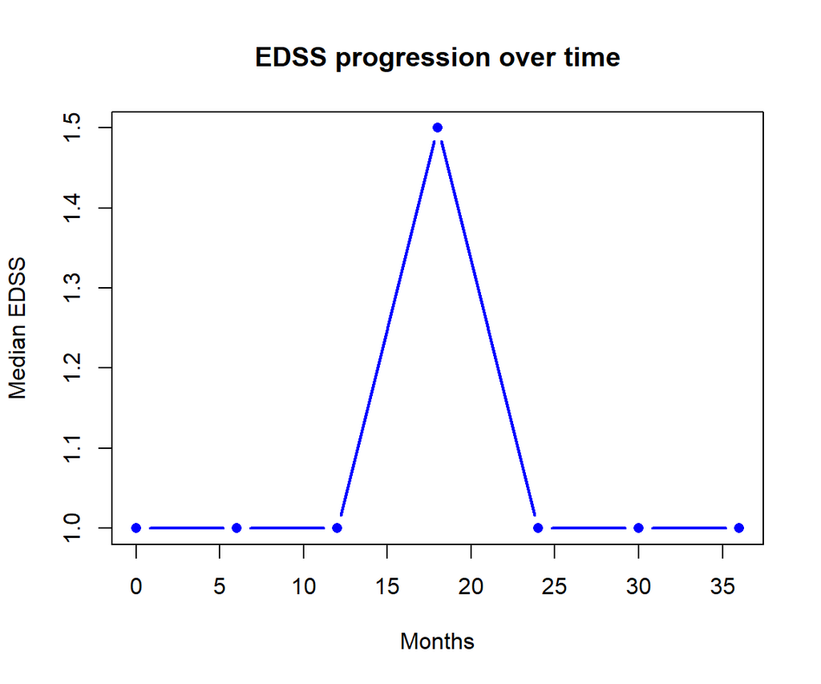

```r
time <- c(0,6,12,18,24,30,36)

plot(time,
     medians,
     type="b",
     pch=16,
     col="blue",
     lwd=2,
     xlab="Months",
     ylab="Median EDSS",
     main="EDSS progression over time")
```

The graphical representation confirms the explained pattern.

This trend supports the presence of transient fluctuations in disability, without evidence of sustained progression over time.

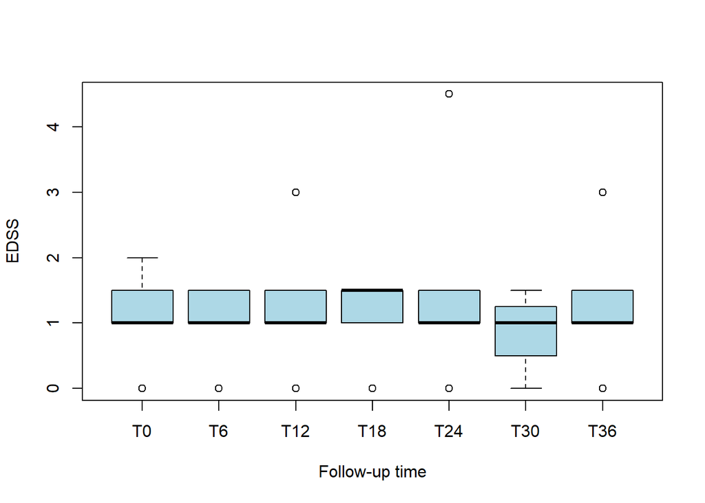

```r
boxplot(
  merged$EDSS_T0,
  merged$EDSS_T6,
  merged$EDSS_T12,
  merged$EDSS_T18,
  merged$EDSS_T24,
  merged$EDSS_T30,
  merged$EDSS_T36,

  names=c("T0","T6","T12","T18","T24","T30","T36"),
  col="lightblue",
  ylab="EDSS",
  xlab="Follow-up time"
)
```

The boxplots provide a clear view of the distribution and variability of EDSS scores across time points. In addition, the IQRs remain relatively stable, indicating moderate variability in disability levels within the cohort.

However, the presence of several outliers at different time points highlights a degree of inter-individual heterogeneity: both lower and higher EDSS values are observed, suggesting that a subset of patient experiences more pronounced changes.

These findings emphasize that, on one hand there’s a general stability at the group level, on the other individual patient trajectories may differ substantially over time.

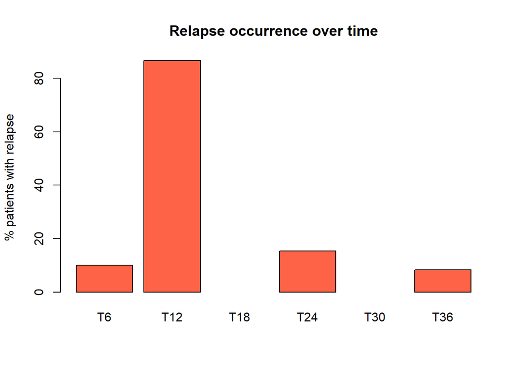

```r
relapse_perc <- c(
  prop.table(table(merged$relapse_T6))[2]*100,
  prop.table(table(merged$relapse_T12))[2]*100,
  prop.table(table(merged$relapse_T18))[2]*100,
  prop.table(table(merged$relapse_T24))[2]*100,
  prop.table(table(merged$relapse_T30))[2]*100,
  prop.table(table(merged$relapse_T36))[2]*100
)

time <- c("T6","T12","T18","T24", "T30", "T36")

barplot(relapse_perc,
        names.arg=time,
        col="tomato",
        ylab="% patients with relapse",
        main="Relapse occurrence over time")
```

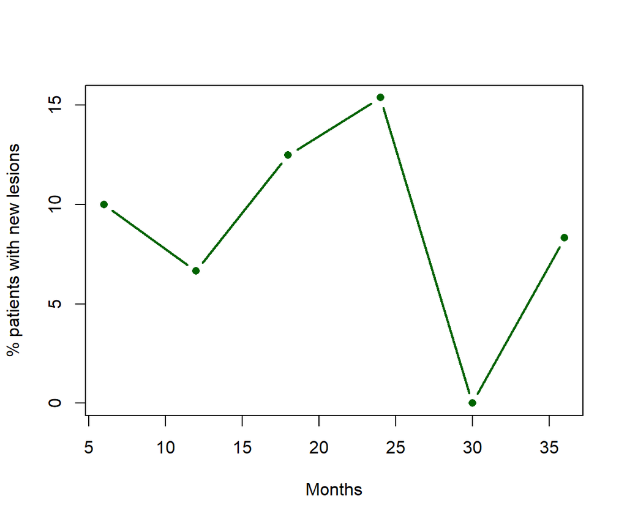

```r
lesioni_perc <- c(
  mean(merged$lesioni_T6 == "1", na.rm=TRUE) * 100,
  mean(merged$lesioni_T12 == "1", na.rm=TRUE) * 100,
  mean(merged$lesioni_T18 == "1", na.rm=TRUE) * 100,
  mean(merged$lesioni_T24 == "1", na.rm=TRUE) * 100,
  mean(merged$lesioni_T30 == "1", na.rm=TRUE) * 100,
  mean(merged$lesioni_T36 == "1", na.rm=TRUE) * 100
)

plot(c(6,12,18,24,30,36),
     lesioni_perc,
     type="b",
     pch=16,
     lwd=2,
     col="darkgreen",
     xlab="Months",
     ylab="% patients with new lesions")
```

```r
table(merged$cortisone_T6)
```

```
##
## 0 4
## 9 1
```

```r
prop.table(table(merged$cortisone_T6))*100
```

```
##
##  0  4
## 90 10
```

```r
table(merged$cortisone_T12)
```

```
##
##  0  3
## 14  1
```

```r
prop.table(table(merged$cortisone_T12))*100
```

```
##
##         0         3
## 93.333333  6.666667
```

```r
table(merged$cortisone_T18)
```

```
##
## 0
## 9
```

```r
prop.table(table(merged$cortisone_T18))*100
```

```
##
##   0
## 100
```

```r
table(merged$cortisone_T24)
```

```
##
##  0  4
## 12  1
```

```r
prop.table(table(merged$cortisone_T24))*100
```

```
##
##         0         4
## 92.307692  7.692308
```

```r
table(merged$cortisone_T30)
```

```
##
## 0
## 7
```

```r
prop.table(table(merged$cortisone_T30))*100
```

```
##
##   0
## 100
```

```r
table(merged$cortisone_T36)
```

```
##
##  0  3
## 11  1
```

```r
prop.table(table(merged$cortisone_T36))*100
```

```
##
##         0         3
## 91.666667  8.333333
```

The proportion of patients receiving corticosteroid treatment during follow-up remained low across all time points, usually involving a small percentage of the population. This pattern is consistent with the clinical use of corticosteroids in multiple sclerosis, where they are typically used on demand to manage acute relapses and associated symptoms, such as functional impairment or pain.

### Data Transformation to Long Format

To better investigate longitudinal patterns, the dataset was reshaped from wide to long format. This modification permits a more flexible analysis of repeated measurements during follow-up and facilitates the use of advanced graphical and statistical methods.

In the long format dataset, each row corresponds to a single measurement at a specific time point for each patient, to have a more detailed representation of temporal trends in EDSS scores, relapses, lesion occurrence, and corticosteroid use.

```r
merged <- merged %>%
  mutate(
    across(
      matches("^(relapse|lesioni|cortisone)_T"),
      ~ as.character(.)
    )
  )


long_data <- merged %>%

  pivot_longer(
    cols = matches("^(EDSS|relapse|lesion|cortisone)_T"),
    names_to = c(".value", "time"),
    names_pattern = "(.*)_T(.*)"
  )

head(long_data)
```

```
## # A tibble: 6 × 60
##   ID    data_di_nascita MEDAS CENTRO DATA_ESORDIO data_diagnosi age_at_diagnosis
##   <chr> <chr>           <dbl> <chr>  <chr>        <chr>                    <int>
## 1 TEC01 1984-03-13         50 CLERI… 2015-01-01   2017-05-11                  33
## 2 TEC01 1984-03-13         50 CLERI… 2015-01-01   2017-05-11                  33
## 3 TEC01 1984-03-13         50 CLERI… 2015-01-01   2017-05-11                  33
## 4 TEC01 1984-03-13         50 CLERI… 2015-01-01   2017-05-11                  33
## 5 TEC01 1984-03-13         50 CLERI… 2015-01-01   2017-05-11                  33
## 6 TEC01 1984-03-13         50 CLERI… 2015-01-01   2017-05-11                  33
## # ℹ 53 more variables: data_prelievo_T0 <chr>, data_referto_T6 <chr>,
## #   lesioni_T6 <chr>, data_referto_T12 <chr>, lesioni_T12 <chr>,
## #   data_referto_T18 <chr>, lesioni_T18 <chr>, data_referto_T24 <chr>,
## #   lesioni_T24 <chr>, data_referto_T30 <chr>, lesioni_T30 <chr>,
## #   data_referto_T36 <chr>, lesioni_T36 <chr>, cambio_terapia <int>,
## #   data_cambio_terapia <chr>, nuova_TERAPIA <chr>, NOTE <chr>, therapy <chr>,
## #   naive <chr>, previous_therapy <chr>, sex <chr>, age <int>, …
```

```r
str(long_data)
```

```
## tibble [224 × 60] (S3: tbl_df/tbl/data.frame)
##  $ ID                      : chr [1:224] "TEC01" "TEC01" "TEC01" "TEC01" ...
##  $ data_di_nascita         : chr [1:224] "1984-03-13" "1984-03-13" "1984-03-13" "1984-03-13" ...
##  $ MEDAS                   : num [1:224] 50 50 50 50 50 50 50 42.9 42.9 42.9 ...
##  $ CENTRO                  : chr [1:224] "CLERICO" "CLERICO" "CLERICO" "CLERICO" ...
##  $ DATA_ESORDIO            : chr [1:224] "2015-01-01" "2015-01-01" "2015-01-01" "2015-01-01" ...
##  $ data_diagnosi           : chr [1:224] "2017-05-11" "2017-05-11" "2017-05-11" "2017-05-11" ...
##  $ age_at_diagnosis        : int [1:224] 33 33 33 33 33 33 33 44 44 44 ...
##  $ data_prelievo_T0        : chr [1:224] "2019-10-07" "2019-10-07" "2019-10-07" "2019-10-07" ...
##  $ data_referto_T6         : chr [1:224] NA NA NA NA ...
##  $ lesioni_T6              : chr [1:224] "0" "0" "0" "0" ...
##  $ data_referto_T12        : chr [1:224] NA NA NA NA ...
##  $ lesioni_T12             : chr [1:224] "0" "0" "0" "0" ...
##  $ data_referto_T18        : chr [1:224] "2021-09-01" "2021-09-01" "2021-09-01" "2021-09-01" ...
##  $ lesioni_T18             : chr [1:224] "0" "0" "0" "0" ...
```

[output cut: 46 more lines]

```r
# trasformo time in numerico
long_data$time <- as.numeric(long_data$time)
str(long_data)
```

```
## tibble [224 × 60] (S3: tbl_df/tbl/data.frame)
##  $ ID                      : chr [1:224] "TEC01" "TEC01" "TEC01" "TEC01" ...
##  $ data_di_nascita         : chr [1:224] "1984-03-13" "1984-03-13" "1984-03-13" "1984-03-13" ...
##  $ MEDAS                   : num [1:224] 50 50 50 50 50 50 50 42.9 42.9 42.9 ...
##  $ CENTRO                  : chr [1:224] "CLERICO" "CLERICO" "CLERICO" "CLERICO" ...
##  $ DATA_ESORDIO            : chr [1:224] "2015-01-01" "2015-01-01" "2015-01-01" "2015-01-01" ...
##  $ data_diagnosi           : chr [1:224] "2017-05-11" "2017-05-11" "2017-05-11" "2017-05-11" ...
##  $ age_at_diagnosis        : int [1:224] 33 33 33 33 33 33 33 44 44 44 ...
##  $ data_prelievo_T0        : chr [1:224] "2019-10-07" "2019-10-07" "2019-10-07" "2019-10-07" ...
##  $ data_referto_T6         : chr [1:224] NA NA NA NA ...
##  $ lesioni_T6              : chr [1:224] "0" "0" "0" "0" ...
##  $ data_referto_T12        : chr [1:224] NA NA NA NA ...
##  $ lesioni_T12             : chr [1:224] "0" "0" "0" "0" ...
##  $ data_referto_T18        : chr [1:224] "2021-09-01" "2021-09-01" "2021-09-01" "2021-09-01" ...
##  $ lesioni_T18             : chr [1:224] "0" "0" "0" "0" ...
```

[output cut: 46 more lines]

In this dataset repeated measurements are organized in a longitudinal structure.

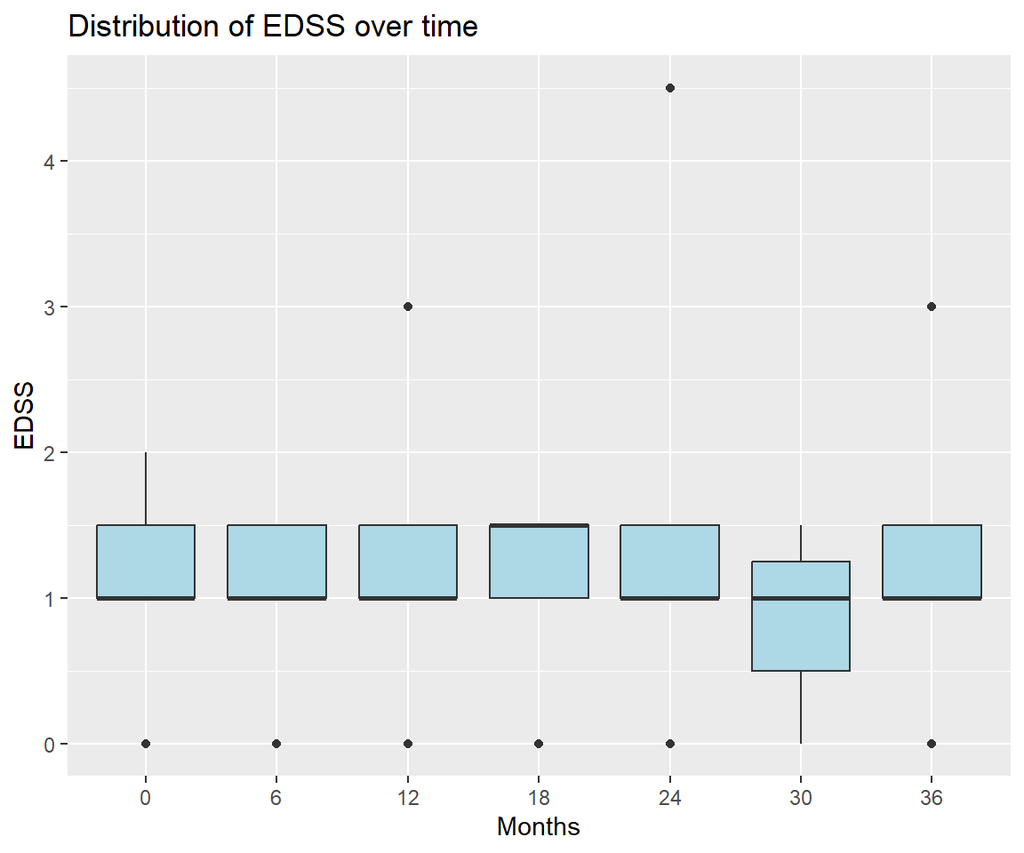

```r
ggplot(long_data,
       aes(x = factor(time), y = EDSS)) +

  geom_boxplot(fill = "lightblue") +

  xlab("Months") +
  ylab("EDSS") +
  ggtitle("Distribution of EDSS over time")
```

The boxplot is consistent with the previous analyses, confirming the distribution of EDSS values in different time points. The graphic highlights the same general structure of the data, with relatively stable central values and limited variability within the study cohort.

The use of the long format allows for a more standardized visualization of repeated measures, facilitating further longitudinal analyses and improving the interpretability of patterns across time.

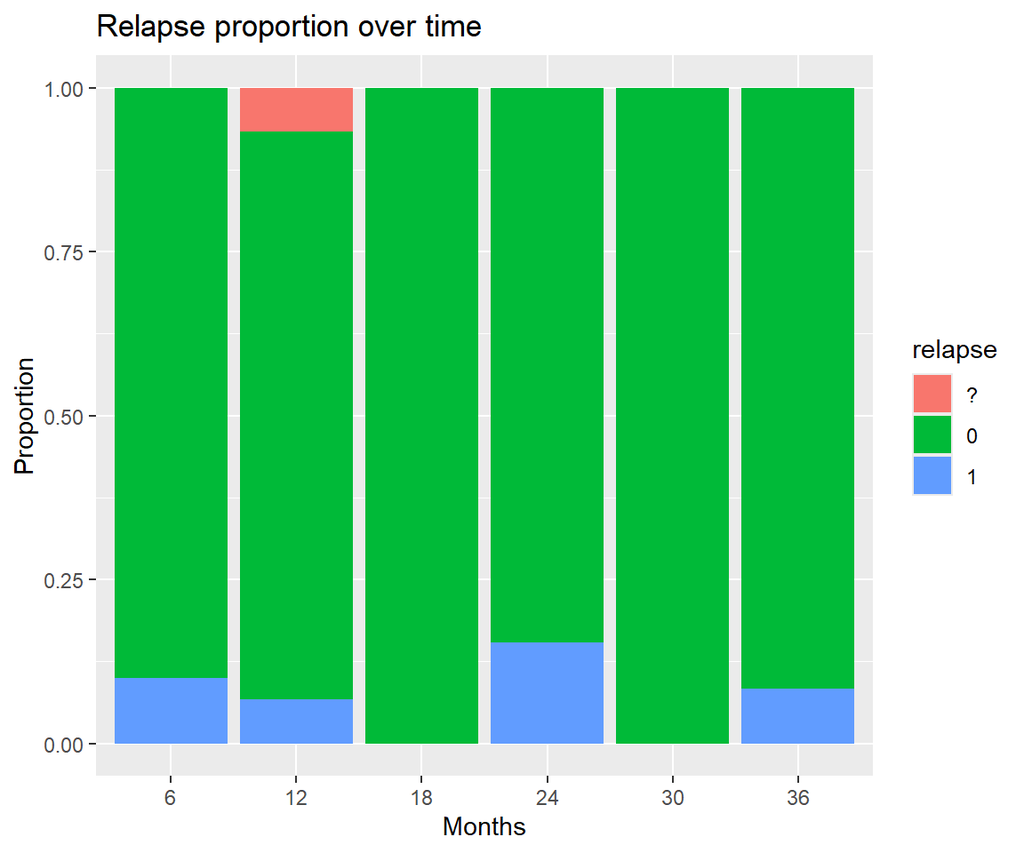

```r
ggplot(long_data %>% filter(!is.na(relapse)),
       aes(x = factor(time),
           fill = relapse)) +

  geom_bar(position = "fill") +

  ylab("Proportion") +
  xlab("Months") +
  ggtitle("Relapse proportion over time")
```

The proportional bar plot confirms the previously observed fluctuating pattern of relapse occurrence over time. After excluding NA values, the distribution highlights variability in relapse rates across follow-up visits, without evidence of a consistent temporal trend.

```r
long_data %>%

  group_by(time) %>%

  summarise(
    relapse_rate = mean(relapse == "1", na.rm = TRUE) * 100
  )
```

```
## # A tibble: 7 × 2
##    time relapse_rate
##   <dbl>        <dbl>
## 1     0       NaN
## 2     6        10
## 3    12         6.67
## 4    18         0
## 5    24        15.4
## 6    30         0
## 7    36         8.33
```

### Inferential Analysis: Friedman Test

To formally assess if disability changed over time, a Friedman test was performed on repeated EDSS values. This test allows for the evaluation of differences in median values across different time points. In the analysis, just a subset of patients with complete EDSS measurements across time points (T0, T6, T12, T24) were considered, in order to ensure comparability of repeated observations. As a result, the sample size was reduced compared to the full dataset, which should be considered when interpreting the findings.

```r
# selezione delle variabili EDSS
edss_data_short <- merged %>%
  select(ID, EDSS_T0, EDSS_T6, EDSS_T12, EDSS_T24)

# mantengo solo soggetti completi
edss_complete_short <- na.omit(edss_data_short)

# controllo dimensione
dim(edss_complete_short)
```

```
## [1] 8 5
```

```r
# esecuzione test
friedman.test(
  as.matrix(edss_complete_short[, -1])
)
```

```
##
##  Friedman rank sum test
##
## data:  as.matrix(edss_complete_short[, -1])
## Friedman chi-squared = 2.2, df = 3, p-value = 0.5319
```

The Friedman test did not show a statistically significant difference in EDSS scores across time points (p = 0.53), suggesting that disability levels remained stable during follow-up.

This result is consistent with the descriptive analysis, which showed only transient fluctuations in EDSS without a clear pattern of progression. In conclusion, the observed changes in EDSS scores over time are likely attributable to random variation rather than a meaningful change in the clinical status of the cohort.

### Inferential Analysis of Relapse: Cochran’s Q Test

To assess if the frequency of relapse changed over time, a Cochran’s Q test was performed on repeated binary relapse data.

```r
relapse_data <- merged %>%
  select(
    relapse_T6,
    relapse_T12,
    relapse_T18,
    relapse_T24,
    relapse_T30,
    relapse_T36
  ) %>%
  mutate(
    across(everything(), ~ as.numeric(as.character(.)))
  )
CochranQTest(as.matrix(relapse_data))
```

```
##
##  Cochran's Q test
##
## data:  y
## Q = NaN, df = 5, p-value = NA
```

### Inferential Analysis of Radiological Activity: Cochran’s Q Test

A Cochran’s Q test was also performed to evaluate if the occurrence of new lesions changed over time, using time points with sufficient variability.

```r
# selezione dei timepoint con sufficiente variabilità
lesion_data <- merged %>%
  select(
    lesioni_T6,
    lesioni_T12,
    lesioni_T18
  ) %>%
  mutate(
    across(everything(), ~ as.numeric(as.character(.)))
  )

# rimozione dei missing
lesion_complete <- na.omit(lesion_data)

# esecuzione test
CochranQTest(as.matrix(lesion_complete))
```

```
##
##  Cochran's Q test
##
## data:  y
## Q = NaN, df = 2, p-value = NA
```

The Cochran’s Q test could not be computed for lesion occurrence across time points, resulting in missing test statistics. This issue is likely due to the limited variability in the data and the small number of complete observations after excluding NA values.

These results provide a basis for subsequent comparative analyses between patient subgroups.

```r
merged$MEDAS_group <- ifelse(
  merged$MEDAS >= median(merged$MEDAS, na.rm=TRUE),
  "High", "Low"
)

merged$BMI_group <- case_when(
  merged$bmi < 25 ~ "Normal",
  merged$bmi >= 25 ~ "Overweight"
)
```

```r
wilcox.test(EDSS_T24 ~ MEDAS_group, data = merged)
```

```
##
##  Wilcoxon rank sum test with continuity correction
##
## data:  EDSS_T24 by MEDAS_group
## W = 19, p-value = 0.4951
## alternative hypothesis: true location shift is not equal to 0
```

```r
kruskal.test(EDSS_T24 ~ physical_activity, data = merged)
```

```
##
##  Kruskal-Wallis rank sum test
##
## data:  EDSS_T24 by physical_activity
## Kruskal-Wallis chi-squared = 1.9818, df = 2, p-value = 0.3712
```

```r
wilcox.test(EDSS_T24 ~ smoking_habit, data = merged, exact = FALSE)
```

```
##
##  Wilcoxon rank sum test with continuity correction
##
## data:  EDSS_T24 by smoking_habit
## W = 30.5, p-value = 0.7052
## alternative hypothesis: true location shift is not equal to 0
```

```r
wilcox.test(EDSS_T24 ~ sex, data = merged, exact = FALSE)
```

```
##
##  Wilcoxon rank sum test with continuity correction
##
## data:  EDSS_T24 by sex
## W = 30.5, p-value = 0.7052
## alternative hypothesis: true location shift is not equal to 0
```

```r
wilcox.test(EDSS_T24 ~ naive, data = merged, exact = FALSE)
```

```
##
##  Wilcoxon rank sum test with continuity correction
##
## data:  EDSS_T24 by naive
## W = 25, p-value = 0.7758
## alternative hypothesis: true location shift is not equal to 0
```

```r
wilcox.test(EDSS_T24 ~ BMI_group, data = merged, exact = FALSE)
```

```
##
##  Wilcoxon rank sum test with continuity correction
##
## data:  EDSS_T24 by BMI_group
## W = 16.5, p-value = 0.3345
## alternative hypothesis: true location shift is not equal to 0
```

The comparative analysis didn’t reveal statistically significant differences in EDSS scores at T24 across the cohort. No significant associations were observed with MEDAS, physical activity, smoking habit, sex, treatment status (naïve or not), or BMI (all p > 0.05).

```r
fisher.test(table(merged$MEDAS_group, merged$relapse_T24))
```

```
##
##  Fisher's Exact Test for Count Data
##
## data:  table(merged$MEDAS_group, merged$relapse_T24)
## p-value = 1
## alternative hypothesis: true odds ratio is not equal to 1
## 95 percent confidence interval:
##   0.01064594 93.93251397
## sample estimates:
## odds ratio
##          1
```

```r
fisher.test(table(merged$physical_activity, merged$relapse_T24))
```

```
##
##  Fisher's Exact Test for Count Data
##
## data:  table(merged$physical_activity, merged$relapse_T24)
## p-value = 1
## alternative hypothesis: two.sided
```

```r
fisher.test(table(merged$smoking_habit, merged$relapse_T24))
```

```
##
##  Fisher's Exact Test for Count Data
##
## data:  table(merged$smoking_habit, merged$relapse_T24)
## p-value = 1
## alternative hypothesis: true odds ratio is not equal to 1
## 95 percent confidence interval:
##    0.01277144 109.58633095
## sample estimates:
## odds ratio
##   1.183213
```

```r
fisher.test(table(merged$BMI_group, merged$relapse_T24))
```

```
##
##  Fisher's Exact Test for Count Data
##
## data:  table(merged$BMI_group, merged$relapse_T24)
## p-value = 0.4545
## alternative hypothesis: true odds ratio is not equal to 1
## 95 percent confidence interval:
##  0.1938361       Inf
## sample estimates:
## odds ratio
##        Inf
```

```r
fisher.test(table(merged$naive, merged$relapse_T24))
```

```
##
##  Fisher's Exact Test for Count Data
##
## data:  table(merged$naive, merged$relapse_T24)
## p-value = 0.4697
## alternative hypothesis: true odds ratio is not equal to 1
## 95 percent confidence interval:
##  0.1339354       Inf
## sample estimates:
## odds ratio
##        Inf
```

Also in this case, the comparative analysis did not reveal statistically significant differences in relapse frequency at T24 across the groups considered. As before, no significant associations were observed with MEDAS score, physical activity, smoking habit, BMI, or treatment status (all p > 0.05).

No clear association between characteristics at T0 and relapse occurrence was discovered within this study population.

```r
fisher.test(table(merged$MEDAS_group, merged$full_recovery))
```

```
##
##  Fisher's Exact Test for Count Data
##
## data:  table(merged$MEDAS_group, merged$full_recovery)
## p-value = 1
## alternative hypothesis: true odds ratio is not equal to 1
## 95 percent confidence interval:
##   0.06733166 22.01145335
## sample estimates:
## odds ratio
##   1.114026
```

```r
fisher.test(table(merged$physical_activity, merged$full_recovery))
```

```
##
##  Fisher's Exact Test for Count Data
##
## data:  table(merged$physical_activity, merged$full_recovery)
## p-value = 0.5105
## alternative hypothesis: two.sided
```

```r
fisher.test(table(merged$BMI_group, merged$full_recovery))
```

```
##
##  Fisher's Exact Test for Count Data
##
## data:  table(merged$BMI_group, merged$full_recovery)
## p-value = 1
## alternative hypothesis: true odds ratio is not equal to 1
## 95 percent confidence interval:
##   0.03691759 10.13700749
## sample estimates:
## odds ratio
##  0.6878282
```

The comparative analysis did not show statistically significant differences in full recovery across the groups considered. No significant associations were observed with dietary adherence (MEDAS), physical activity, or BMI (all p > 0.05).

These findings suggest that the examined variables were not significantly associated with recovery outcomes in this cohort.

### Exploratory Analysis of Disease Progression

To explore clinical outcomes, additional analyses were performed with focus on disability progression and disease activity.

```r
# delta EDSS (progression)
merged$delta_EDSS <- merged$EDSS_T24 - merged$EDSS_T0

# Test between groups MEDAS
wilcox.test(
  delta_EDSS ~ MEDAS_group,
  data = merged,
  exact = FALSE
)
```

```
##
##  Wilcoxon rank sum test with continuity correction
##
## data:  delta_EDSS by MEDAS_group
## W = 24, p-value = 1
## alternative hypothesis: true location shift is not equal to 0
```

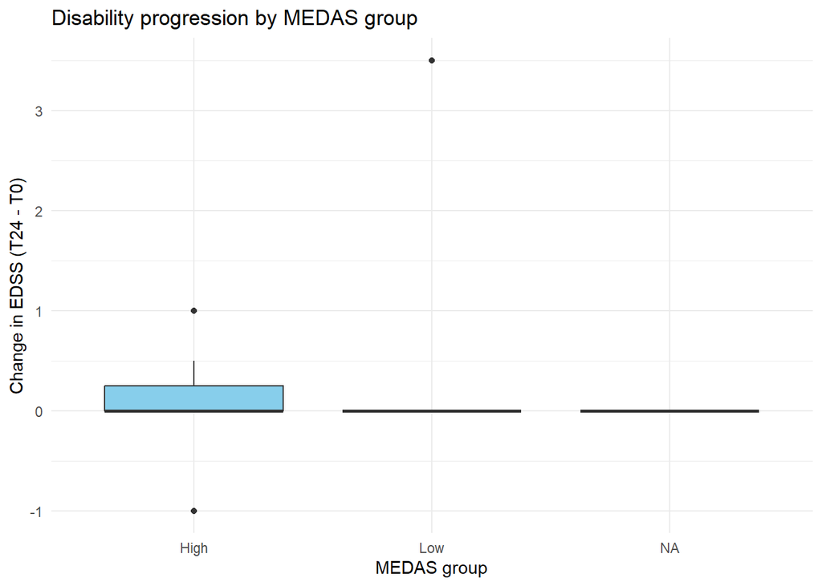

```r
# Boxplot
ggplot(
  merged,
  aes(
    x = MEDAS_group,
    y = delta_EDSS
  )
) +
  geom_boxplot(fill = "skyblue") +
  theme_minimal() +
  xlab("MEDAS group") +
  ylab("Change in EDSS (T24 - T0)") +
  ggtitle("Disability progression by MEDAS group")
```

The analysis of EDSS values between T0 and T24 showed no clear differences between MEDAS groups.

Most patients showed stable disability over time, with delta EDSS values close to zero in both groups. Some variability in individual cases or worsening were observed, but no consistent pattern emerged between high and low MEDAS adherence.

These findings suggest that, for these patients, adherence to Mediterranean diet was not associated with disability progression.

```r
merged$disease_activity <- ifelse(
  merged$relapse_T24 == "1" |
  merged$lesioni_T24 == "1" |
  merged$delta_EDSS > 0,
  "Yes",
  "No"
)

# Test between groups
fisher.test(
  table(
    merged$MEDAS_group,
    merged$disease_activity
  )
)
```

```
##
##  Fisher's Exact Test for Count Data
##
## data:  table(merged$MEDAS_group, merged$disease_activity)
## p-value = 1
## alternative hypothesis: true odds ratio is not equal to 1
## 95 percent confidence interval:
##   0.04802443 20.82273599
## sample estimates:
## odds ratio
##          1
```

The analysis of the outcome of composite disease activity did not reveal a statistically significant association with MEDAS group (p = 1).

The part of patients classified as having active disease was similar between MEDAS groups, indicating that, in general, MEDAS score was not associated with disease activity.

### Correlation Analysis

To further explore potential associations between continuous variables and disability scores, Spearman correlation analyses were performed.

```r
cor.test(merged$MEDAS, merged$EDSS_T24,
         method = "spearman", exact = FALSE)
```

```
##
##  Spearman's rank correlation rho
##
## data:  merged$MEDAS and merged$EDSS_T24
## S = 470.49, p-value = 0.908
## alternative hypothesis: true rho is not equal to 0
## sample estimates:
##         rho
## -0.03403758
```

```r
cor.test(merged$bmi, merged$EDSS_T24,
         method = "spearman", exact = FALSE)
```

```
##
##  Spearman's rank correlation rho
##
## data:  merged$bmi and merged$EDSS_T24
## S = 350.35, p-value = 0.4289
## alternative hypothesis: true rho is not equal to 0
## sample estimates:
##       rho
## 0.2300032
```

```r
cor.test(merged$age_at_T0, merged$EDSS_T24,
         method = "spearman", exact = FALSE)
```

```
##
##  Spearman's rank correlation rho
##
## data:  merged$age_at_T0 and merged$EDSS_T24
## S = 123.43, p-value = 0.0006104
## alternative hypothesis: true rho is not equal to 0
## sample estimates:
##       rho
## 0.7795944
```

No significant correlations were observed between EDSS and MEDAS score or BMI (both p > 0.05). These results indicate the absence of important association between these variables and EDSS levels.

This finding is consistent with the clinical expectation, indeed disability levels tend to increase with age.

### Conclusion

Overall, the analyses suggest a generally stable disease course within the study population, characterized by limited progression of disability and fluctuations but non-persistent radiological activity over time.

No significant associations were identified between lifestyle or clinical variables and the main clinical outcomes. In contrast, age emerged as a relevant factor, showing a significant association with disability levels.

These findings highlight the complexity of multiple sclerosis progression and suggest that the examined factors may have a limited impact on short-term clinical outcomes.